# Circular GLMM Summary: Four Conditions

James Foster

2026-10-14

# Details

**DESCRIPTION**

Load and plot the circular GLMM fitted in `HS_circGLMM_fit_4cond.ipynb` to describe waggle-run angles relative to the feeder for dances in the vertical, horizontal, antisolar and solar conditions at medium solar elevations. The model to summarise is set by `params$model_file` (by default, the model with the looser individual-level prior, `2Results/HS_unwrap_4cond_wideInd.nc`; the strict-prior model is `2Results/HS_unwrap_4cond.nc`).

**INPUTS**

`HS_functions.R`, `0Data/hs_dance_reorg.csv`, `0Data/hs_dance_medel_4cond.feather`, `2Results/HS_unwrap_4cond_wideInd.nc` or `2Results/HS_unwrap_4cond.nc`

**OUTPUTS**

Plotted estimates, predictions and contrasts.

**REFERENCES**

**modelling methods**

- Sayin S, … Graving JM, $\textit{et~al}$.(2025) The behavioral mechanisms governing collective motion in swarming locusts. $\textit{Science}$ 387,995-1000 [DOI:10.1126/science.adq7832](https://doi.org/10.1126/science.adq7832)
- Graving JM, Sayin S, Costelloe BR, Goldshtein A & Foster JJ. Unwrapping circular statistics with Bayesian multilevel models.
- Abril-Pla, O., Andreani, V., Carroll, C., Dong, L., Fonnesbeck, C. J., Kochurov, M., Kumar, R., Lao, J., Luhmann, C. C., Martin, O. A., et al. (2023). `PyMC`: a modern, and comprehensive probabilistic programming framework in Python. *PeerJ Computer Science* 9, e1516.
- Capretto, T., Piho, C., Kumar, R., Westfall, J., Yarkoni, T., & Martin, O.
  2022. `Bambi`: A simple interface for fitting Bayesian linear models in Python. *Journal of Statistical Software* 103(15), 1-29. doi:10.18637/jss.v103.i15
- Seyboldt, A., Carlson, E. L., & Carpenter, B. (2026). Preconditioning Hamiltonian Monte Carlo by minimizing Fisher Divergence. *arXiv* preprint arXiv:2603.18845.

# Motivation

Dances on a vertical comb transpose the sun’s azimuth into the direction of gravity, whereas dances on a horizontal comb, or under solar or antisolar skylight, are oriented relative to the visible sky. Here we compare the mean direction ($\mu$) and directional consistency ($\kappa$) of waggle runs relative to the feeder between these four conditions, at medium solar elevations ($30° <$ `sun_el` $< 45°$).

The model fitted was:

$\mu \sim$ H + A + S + (1 + H + A + S |Individual) + (1 |Dance)

$\kappa \sim$ H + A + S + (1 + H + A + S |Individual) + (1 |Dance)

where the vertical condition is the reference (Intercept), and condition effects are coded as successive differences, progressing vertical → horizontal → antisolar → solar:

| condition | H | A | S | $\mu$ |
| --- | --- | --- | --- | --- |
| vertical | 0 | 0 | 0 | Intercept |
| horizontal | 1 | 0 | 0 | Intercept + H |
| antisolar | 1 | 1 | 0 | Intercept + H + A |
| solar | 1 | 1 | 1 | Intercept + H + A + S |

so that H is the effect of horizontal orientation (horizontal − vertical), A is the effect of antisolar skylight (antisolar − horizontal) and S is the effect of solar skylight (solar − antisolar). The individual-level effects on $\mu$ may use either the strict (LogNormal(log 30, 0.6)) or looser (LogNormal(log 10, 1)) prior on their concentration; the dance-level prior is restrictive (LogNormal(log 30, 0.6)) in both. Each dance was performed in a single condition, so dances (nested within individuals) have random intercepts only.

# Set up workspace

To extract these models, we need to load the appropriate functions. Make sure that the `circular`, `reticulate`, `arrow`, `posterior` and `bayesplot` packages are installed. Here we use the `HS-env` conda environment created for `HS_circGLMM_fit_4cond.ipynb`, so that `arviz` can read the saved model.

```r
source('HS_functions.R')
require(reticulate) #run python from R
use_condaenv("HS-env",
             required = TRUE)
reticulate::py_config()
```

```
## python:         /opt/miniconda3/envs/HS-env/bin/python
## libpython:      /opt/miniconda3/envs/HS-env/lib/libpython3.12.dylib
## pythonhome:     /opt/miniconda3/envs/HS-env:/opt/miniconda3/envs/HS-env
## version:        3.12.15 (main, Oct 13 2026, 17:19:37) [Clang 21.1.8 ]
## numpy:          /opt/miniconda3/envs/HS-env/lib/python3.12/site-packages/numpy
## numpy_version:  1.26.4
##
## NOTE: Python version was forced by use_python() function
```

```r
#load .feather files (readable in R and Python)
require(arrow)
```

```r
#process and plot MCMC data
require(posterior)
require(bayesplot)
options(posterior.num_args = list(sigfig = 3))#for ease of reading

#condition colours, as in HS_ExploratoryPlots.Rmd
cond_cols = list(
  vertical = 'darkred',
  horizontal = 'darkgreen',
  antisolar = 'cyan4',
  solar = 'blue4'
)
#conditions, reference first, and the successive model effects for each
conds = c('vertical', 'horizontal', 'antisolar', 'solar')
cond_effs = list(vertical = character(0),
                 horizontal = c('H'),
                 antisolar = c('H', 'A'),
                 solar = c('H', 'A', 'S'))
```

# Prepare data

Then load the data that will be used. This is our dance data, reorganised as `hs_dance_reorg.csv`, from which we select the same subset as in `HS_circGLMM_fit_4cond.ipynb`.

```r
#Dance angle data
hd = read.table(file = '0Data/hs_dance_reorg.csv',
                header = T,
                sep  = ',')
#select medium elevations and the conditions of interest
medel_min = 30 # degrees
medel_max = 45 # degrees
hd = subset(hd,
            sun_el > medel_min &
              sun_el < medel_max &
              condition %in% conds
            )
head(hd)
```

```
##     waggle_run condition                         csv_file
## 376          1  vertical 22b_00011_waggle_annotations.csv
## 377          2  vertical 22b_00011_waggle_annotations.csv
## 378          3  vertical 22b_00011_waggle_annotations.csv
## 379          4  vertical 22b_00011_waggle_annotations.csv
## 380          5  vertical 22b_00011_waggle_annotations.csv
## 381          6  vertical 22b_00011_waggle_annotations.csv
##     calibration_quality_flag calibration_R         video_file      day     time
## 376                     <NA>            NA 20250120/00011.mp4 20250120 08:21:00
## 377                     <NA>            NA 20250120/00011.mp4 20250120 08:21:00
## 378                     <NA>            NA 20250120/00011.mp4 20250120 08:21:00
## 379                     <NA>            NA 20250120/00011.mp4 20250120 08:21:00
## 380                     <NA>            NA 20250120/00011.mp4 20250120 08:21:00
## 381                     <NA>            NA 20250120/00011.mp4 20250120 08:21:00
##                            ID_d  ID           sast_time  sun_az   sun_el
## 376 22b_00011_08:21:00_20250120 22b 2025-01-20 08:21:00 96.1665 38.18063
## 377 22b_00011_08:21:00_20250120 22b 2025-01-20 08:21:00 96.1665 38.18063
## 378 22b_00011_08:21:00_20250120 22b 2025-01-20 08:21:00 96.1665 38.18063
## 379 22b_00011_08:21:00_20250120 22b 2025-01-20 08:21:00 96.1665 38.18063
## 380 22b_00011_08:21:00_20250120 22b 2025-01-20 08:21:00 96.1665 38.18063
## 381 22b_00011_08:21:00_20250120 22b 2025-01-20 08:21:00 96.1665 38.18063
##     feeder_az    angle signed_angle dance_sun_angle  bearing feeder_angle
## 376 -28.01284 1.188465     68.09401       -28.07249 428.0940 -0.001040967
## 377 -28.01284 1.214774     69.60145       -26.56505 429.6014  0.025268750
## 378 -28.01284 1.171323     67.11189       -29.05460 427.1119 -0.018182145
## 379 -28.01284 1.126767     64.55899       -31.60750 424.5590 -0.062738623
## 380 -28.01284 1.184481     67.86574       -28.30076 427.8657 -0.005025010
## 381 -28.01284 1.214774     69.60145       -26.56505 429.6014  0.025268750
```

## Format data

Ensure that each variable has the correct data format for subsequent analysis.

```r
hd = within(hd,
            {
              ID = droplevels(as.factor(ID)) # bee identifier as a factor
              ID_d = droplevels(as.factor(ID_d)) # dance identifier as a factor
              condition = factor(condition,
                                 levels = conds)
              angle = feeder_angle # angle relative to feeder, between -pi and pi
              angle_deg = deg(feeder_angle) # in degrees, for plotting
            }
)
u_id = with(hd, unique(ID)) # unique bees
length(u_id)#24 bees
```

```
## [1] 24
```

```r
u_dance = with(hd, unique(ID_d)) # unique dances
length(u_dance)#121 dances
```

```
## [1] 121
```

```r
#dances per individual and condition
with(unique(hd[, c('ID', 'ID_d', 'condition')]),
     table(ID, condition))
```

```
##      condition
## ID    vertical horizontal antisolar solar
##   11r        3          0         0     0
##   16b        1          0         0     0
##   20y        5          5         3     2
##   22b       12          5         3     1
##   23y        1          4         1     0
##   25y        0          1         0     0
##   26y        0          2         0     1
##   47y        1          2         1     0
##   48b        1          0         0     0
##   58r        2          0         0     0
##   60r        2          1         0     0
##   65r        1          0         0     0
##   66b        0          4         0     1
##   69r        0          1         0     0
##   73b        7          3         3     0
##   80b        1          0         0     0
##   81r        0          1         0     0
##   84b        3          4         3     1
##   84r        2          0         0     0
##   87r        3          0         0     0
##   88b        1          3         0     0
##   90r        2          3         5     1
##   94w        0          1         0     0
##   95r        0          0         2     5
```

To align individual and dance numbers from the model with the names in the `data.frame` we need to load these columns from the `pandas` version of the data. This data is saved in a `.feather` file (readable in both `R` and `Python`).

```r
hd_pd = read_feather(file = "0Data/hs_dance_medel_4cond.feather",
                     col_select = c('Individual', 'Dance', 'Dance_label'))
#check that the same rows were selected in the same order
stopifnot(nrow(hd_pd) == nrow(hd),
          all(hd_pd$Dance_label == as.character(hd$ID_d)))
#find individuals and dances
hd = within(hd,
            {
              Individual_nr = hd_pd$Individual
              Dance_nr = hd_pd$Dance
            }
            )
#lookup tables for individuals and dances
id_tab = unique(hd[, c('ID', 'Individual_nr')])
id_tab = id_tab[order(id_tab$Individual_nr), ]
dance_tab = unique(hd[, c('ID_d', 'Dance_nr', 'ID', 'Individual_nr', 'condition')])
dance_tab = dance_tab[order(dance_tab$Dance_nr), ]
n_ind = nrow(id_tab)
n_dance = nrow(dance_tab)
#which individuals danced in which conditions (rows ordered by Individual_nr)
id_cond = sapply(conds,
                 function(cnd)
                 {
                   id_tab$Individual_nr %in%
                     subset(hd, condition %in% cnd)$Individual_nr
                 }
                 )
```

# Load Bambi model and extract draws for each parameter

This loads draws from our fitted Bayesian model’s posterior distribution. Because the model was built and saved in `Python`, we use the `reticulate` package to interface directly with `Python` libraries from within our `R` environment.

**Parameter Structural Hierarchies**

The model parameters are categorised into two groups based on their structural hierarchy: Population-Level (Global) Parameters (`global_params`) and Group-Level (Random) Effects (`group_params`), the latter for both individuals and dances.

Converting the whole posterior to a data frame (`idata$posterior$to_dataframe()`) would cross the individual and dance dimensions (as well as each observation’s predictions), so instead we extract each parameter separately as an array of `chain` $\times$ `draw` ($\times$ level).

```r
# Define Parameter Groupings
global_params = c(
  "Intercept", "H", "A", "S",
  "kappa_Intercept", "kappa_H", "kappa_A", "kappa_S",
  "1|Individual_kappa", "H|Individual_kappa", "A|Individual_kappa", "S|Individual_kappa",
  "1|Dance_kappa",
  "kappa_1|Individual_sigma", "kappa_H|Individual_sigma",
  "kappa_A|Individual_sigma", "kappa_S|Individual_sigma",
  "kappa_1|Dance_sigma"
)

group_params = c(
  "1|Individual", "H|Individual", "A|Individual", "S|Individual", "1|Dance",
  "kappa_1|Individual", "kappa_H|Individual", "kappa_A|Individual", "kappa_S|Individual",
  "kappa_1|Dance"
)

#Import arviz for model handling
az = reticulate::import("arviz")
# Load the NetCDF file
idata = az$from_netcdf(params$model_file)
print(params$model_file)
```

```
## [1] "2Results/HS_unwrap_4cond_wideInd.nc"
```

## Reshaping posterior draws into wide format

Each parameter array is reshaped so that draws run sequentially within each chain, and each level of a group-level effect becomes its own column, named by its level in the model (e.g. `1_Individual_5`, `kappa_1_Dance_17`). The level names are the `Individual` and `Dance` codes from `hs_dance_medel_4cond.feather`.

- **Parameter Extraction**: `py_get_item` extracts each parameter as an `xarray.DataArray`, whose values are converted to an `R` array.
- **Dynamic Pivoting**: Group-level effects have their special syntax characters replaced (| to _) for column safety and are pivoted out into one column per level.
- **Posterior Class Conversion**: The wide data frame is converted into a `draws_df` object using the `posterior` package.

```r
# Reshape posterior draws -------------------------------------------------
post = idata$posterior
draws_list = list()
for(param in c(global_params, group_params))
{
  da = reticulate::py_get_item(post, param)
  vals = da$values # chain x draw (x level)
  if(length(dim(vals)) == 2)
  {
    # draws within chains
    draws_list[[param]] = as.vector(t(vals))
  }else
  {
    dim_name = unlist(da$dims)[3]
    lvls = as.character(reticulate::py_get_item(da$coords, dim_name)$values)
    mat = matrix(aperm(vals, c(2, 1, 3)),
                 ncol = dim(vals)[3])
    clean_base = gsub(pattern = "\\|",
                      replacement =  "_",
                      x =  param)
    for(j in seq_along(lvls))
    {
      draws_list[[paste0(clean_base, "_", lvls[j])]] = mat[, j]
    }
  }
}
n_chains = dim(reticulate::py_get_item(post, 'Intercept')$values)[1]
obs_per_chain = dim(reticulate::py_get_item(post, 'Intercept')$values)[2]
draws_wide = data.frame(.chain = rep(x = 1:n_chains, each = obs_per_chain),
                        .iteration = rep(x = 1:obs_per_chain, times = n_chains),
                        draws_list,
                        check.names = FALSE)
#check that every individual and dance was found
stopifnot(all(paste0("1_Individual_", id_tab$Individual_nr) %in% colnames(draws_wide)),
          all(paste0("1_Dance_", dance_tab$Dance_nr) %in% colnames(draws_wide)))

# Export to draws dataframe
draws_final = posterior::as_draws_df(draws_wide)
```

# Inspect model estimates

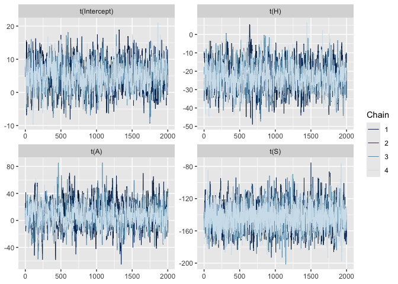

```r
mcmc_trace(draws_final,
           pars = c('Intercept', 'H', 'A', 'S'),
           transformations = unwrap_circular_deg)
```

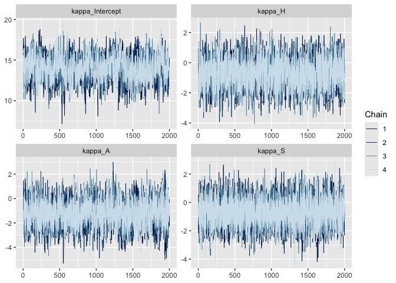

```r
mcmc_trace(draws_final,
           pars = paste0("kappa_",
                         c('Intercept', 'H', 'A', 'S')) )
```

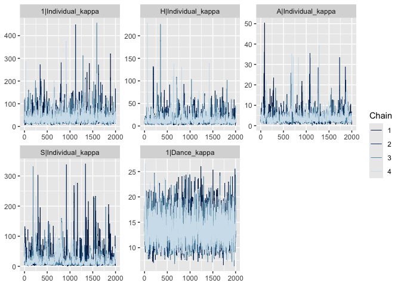

```r
mcmc_trace(draws_final,
           pars = c(paste0(c('1', 'H', 'A', 'S'),
                           '|Individual_kappa'),
                    '1|Dance_kappa') )
```

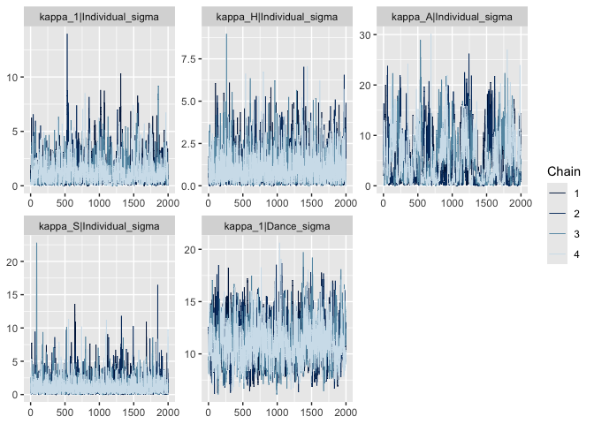

```r
mcmc_trace(draws_final,
           pars = c(paste0('kappa_',
                           c('1', 'H', 'A', 'S'),
                           '|Individual_sigma'),
                    'kappa_1|Dance_sigma') )
```

Check the $\hat{R}$ values for the unwrapped estimates (convergence is indicated by $\hat{R}<1.01$).

```r
azsum_fixed = az$summary(idata,
           var_names=c("Intercept",
                       "H",
                       "A",
                       "S",
                       "kappa_Intercept",
                       "kappa_H",
                       "kappa_A",
                       "kappa_S"
                       ),
    circ_var_names=c("Intercept",
                    "H",
                    "A",
                    "S"
                    )
)
print(azsum_fixed[, c(1, 3, 4, 7, 9)], digits = 3)
```

```
##                   mean hdi_3% hdi_97% ess_bulk r_hat
## Intercept        0.088 -0.039   0.220      975  1.01
## H               -0.402 -0.626  -0.165     1105  1.00
## A                0.137 -0.387   0.729      735  1.01
## S               -2.500 -2.975  -2.006     2019  1.00
## kappa_Intercept 13.949 11.152  16.843      615  1.00
## kappa_H         -0.734 -2.545   1.094     2834  1.00
## kappa_A         -1.237 -3.232   0.835     1278  1.00
## kappa_S         -0.667 -2.590   1.084     5015  1.00
```

```r
azsum_ranef = az$summary(idata,
           var_names=c("1|Individual_kappa",
                       "H|Individual_kappa",
                       "A|Individual_kappa",
                       "S|Individual_kappa",
                       "1|Dance_kappa",
                       "kappa_1|Individual_sigma",
                       "kappa_H|Individual_sigma",
                       "kappa_A|Individual_sigma",
                       "kappa_S|Individual_sigma",
                       "kappa_1|Dance_sigma"
                )
)
print(azsum_ranef[, c(1, 3, 4, 7, 9)], digits = 3)
```

```
##                           mean hdi_3% hdi_97% ess_bulk r_hat
## 1|Individual_kappa       39.90  8.055   86.56     1255  1.00
## H|Individual_kappa       13.65  2.630   31.93      902  1.00
## A|Individual_kappa        3.70  0.586    7.63      616  1.01
## S|Individual_kappa       20.96  0.732   56.74      417  1.02
## 1|Dance_kappa            13.63  8.610   18.84     1682  1.00
## kappa_1|Individual_sigma  1.28  0.001    3.37      939  1.00
## kappa_H|Individual_sigma  1.00  0.000    2.62     1879  1.00
## kappa_A|Individual_sigma  4.62  0.006   12.69      210  1.01
## kappa_S|Individual_sigma  1.19  0.000    3.37     2365  1.00
## kappa_1|Dance_sigma      11.09  7.547   14.73      481  1.01
```

# Extract predictions

To look at the model estimates in context and compare the predictions with the data, we need to extract and summarise the draws. The posterior can be summarised by its quantiles: `quantile(x, probs = c(0.025, 0.975))` identifies the interval containing the central $95\%$ of draws for `x`.

On a circular scale the bounds between which quantiles should be counted are not clearly defined. Since some conditions (e.g. solar) may be oriented near $\pm180°$, we centre each set of draws on its circular median before calculating quantiles, so that the boundary falls far from the bulk of the estimates.

```r
#A function to find the circular median in (-pi, pi)
MedCDraws = function(x,
                     templ = 'none', #assumes radians
                     medn = 1) #take the 1st median
{
  median.circular( circular(x = mod_circular(x),
                            template = templ)
                                           )[medn]
}
#A function to report circular quantiles in degrees, centred on the circular median
QDegDraws = function(x,
                     probs = c(0.5, 0.025, 0.975))
{
  mx = as.numeric(MedCDraws(x))
  round(deg(
    quantile(mod_circular(x - mx), probs = probs) + mx
  ))
}
#A function to report linear quantiles
QDraws = function(x,
                  probs = c(0.5, 0.025, 0.975),
                  digits = 2)
{
  round(quantile(x, probs = probs),
        digits = digits)
}
#Strings for the population-level mean direction and kappa of each condition
#(sums of the successive effects up to that condition)
MuString = function(cnd)
{
  paste(c('Intercept', cond_effs[[cnd]]), collapse = ' + ')
}
KappaString = function(cnd)
{
  effs = cond_effs[[cnd]]
  paste(c('kappa_Intercept', if(length(effs)){paste0('kappa_', effs)}), collapse = ' + ')
}
#Evaluate one of these strings using the draws
EvalDraws = function(string)
{
  with(draws_final, eval(str2lang(string)))
}
```

## Population-level predictions for each condition

```r
pop_draws = list(
  mu = lapply(setNames(conds, conds), function(cnd){EvalDraws(MuString(cnd))}),
  kappa = lapply(setNames(conds, conds), function(cnd){EvalDraws(KappaString(cnd))})
)

pred_table = do.call(rbind,
                     lapply(conds,
                            function(cnd)
                            {
                              mq = QDegDraws(pop_draws$mu[[cnd]])
                              kq = QDraws(softplus(pop_draws$kappa[[cnd]]))
                              rq = QDraws(A1(softplus(pop_draws$kappa[[cnd]])), digits = 3)
                              data.frame(condition = cnd,
                                         mu_median = mq[1], mu_lower = mq[2], mu_upper = mq[3],
                                         kappa_median = kq[1], kappa_lower = kq[2], kappa_upper = kq[3],
                                         rho_median = rq[1], rho_lower = rq[2], rho_upper = rq[3],
                                         row.names = NULL)
                            }
                     )
)
print(pred_table)
```

```
##    condition mu_median mu_lower mu_upper kappa_median kappa_lower kappa_upper
## 1   vertical         5       -3       13        13.99       10.90       16.84
## 2 horizontal       -18      -31       -4        13.17       10.16       16.46
## 3  antisolar       -10      -44       26        11.85        8.37       16.18
## 4      solar      -153     -197     -113        11.19        7.18       16.11
##   rho_median rho_lower rho_upper
## 1      0.964     0.953     0.970
## 2      0.961     0.949     0.969
## 3      0.957     0.938     0.969
## 4      0.954     0.927     0.968
```

## Extracting individual- and dance-specific predictions

This section combines population-level and group-level parameters to compute the posterior predictions for each individual in each condition, and for each dance in the condition in which it was performed.

**Processing Workflow**

- **Dynamic Variable Fetching**: A loop iterates through each individual (or dance) code, fetching that specific individual’s random intercept and condition effect draws from the wide data frame.
- **Linear Combination Reconstruction**: The population-level effects are recombined with the individual-level (and dance-level) deviations to reconstruct the specific direction ($\mu$) and consistency ($\kappa$).
- **Nested Storage Architecture**: The raw vectors are assigned to a nested list (`individual_draws`) to preserve the entire distribution for downstream circular analysis. Concurrently, point-estimate summaries (medians) are calculated and stored in matrices (`mu_id`, `kappa_id`) for the conditions in which each individual danced (otherwise `NA`).

```r
# Setup containers for summary statistics
mu_id = kappa_id = matrix(NA,
                          nrow = n_ind,
                          ncol = length(conds),
                          dimnames = list(NULL, conds))

# Create one Master List for all raw draws
# Structure: individual_draws[[i]]$mu$vertical
individual_draws = vector("list", n_ind)

for(i in id_tab$Individual_nr) {
  # Dynamic fetch of the individual's intercepts
  m_i = draws_final[[paste0("1_Individual_", i)]]
  k_i = draws_final[[paste0("kappa_1_Individual_", i)]]
  individual_draws[[i]] = list(mu = list(), kappa = list())
  for(cnd in conds)
  {
    # Reference condition
    mu_vec = draws_final$Intercept + m_i
    ka_vec = draws_final$kappa_Intercept + k_i
    # Add population and individual successive effects up to this condition
    for(eff in cond_effs[[cnd]])
    {
      mu_vec = mu_vec +
        draws_final[[eff]] + draws_final[[paste0(eff, "_Individual_", i)]]
      ka_vec = ka_vec +
        draws_final[[paste0("kappa_", eff)]] +
        draws_final[[paste0("kappa_", eff, "_Individual_", i)]]
    }
    # Save to the Nested List
    individual_draws[[i]]$mu[[cnd]] = mu_vec
    individual_draws[[i]]$kappa[[cnd]] = ka_vec
    # Store summary stats for conditions in which this individual danced
    if(id_cond[id_tab$Individual_nr == i, cnd])
    {
      mu_id[i, cnd] = MedCDraws(mu_vec)
      kappa_id[i, cnd] = median(ka_vec)
    }
  }
}
```

Each dance was performed in a single condition, so its prediction combines the population, individual and dance-level effects for that condition only.

```r
mu_dance = kappa_dance = numeric(n_dance)

for(d in dance_tab$Dance_nr)
{
  i = dance_tab$Individual_nr[dance_tab$Dance_nr == d]
  cnd = as.character(dance_tab$condition[dance_tab$Dance_nr == d])
  mu_d = individual_draws[[i]]$mu[[cnd]] +
    draws_final[[paste0("1_Dance_", d)]]
  ka_d = individual_draws[[i]]$kappa[[cnd]] +
    draws_final[[paste0("kappa_1_Dance_", d)]]
  mu_dance[d] = MedCDraws(mu_d)
  kappa_dance[d] = median(ka_d)
}
```

### Visualising individual predictions

This section loops through individual bees to plot observed waggle$~$runs against the model’s posterior predictions for each condition. The raw circular data are displayed alongside density contours derived from the joint posterior distribution of $\mu$ and $\kappa$ for that individual. Thin arrows show the median estimated mean$~$vector for each dance, and the thick arrow shows the median estimated mean$~$vector for the individual. Conditions in which an individual did not dance are left blank.

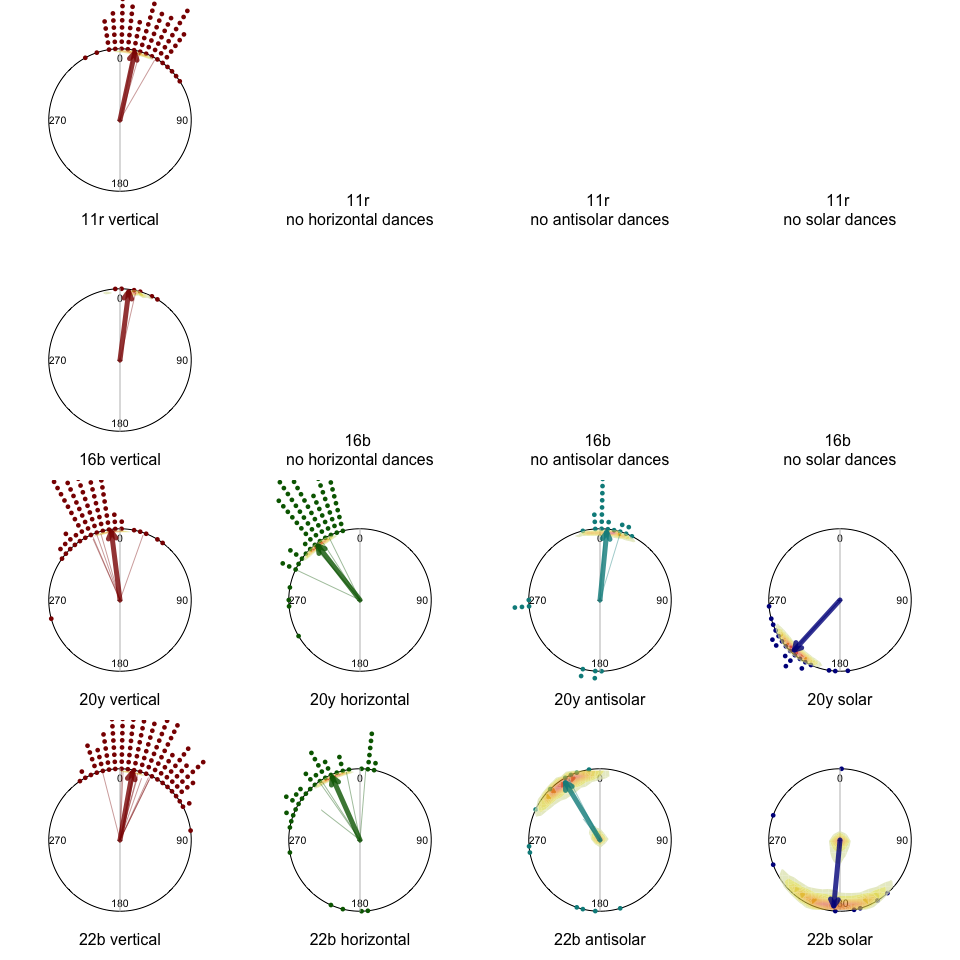

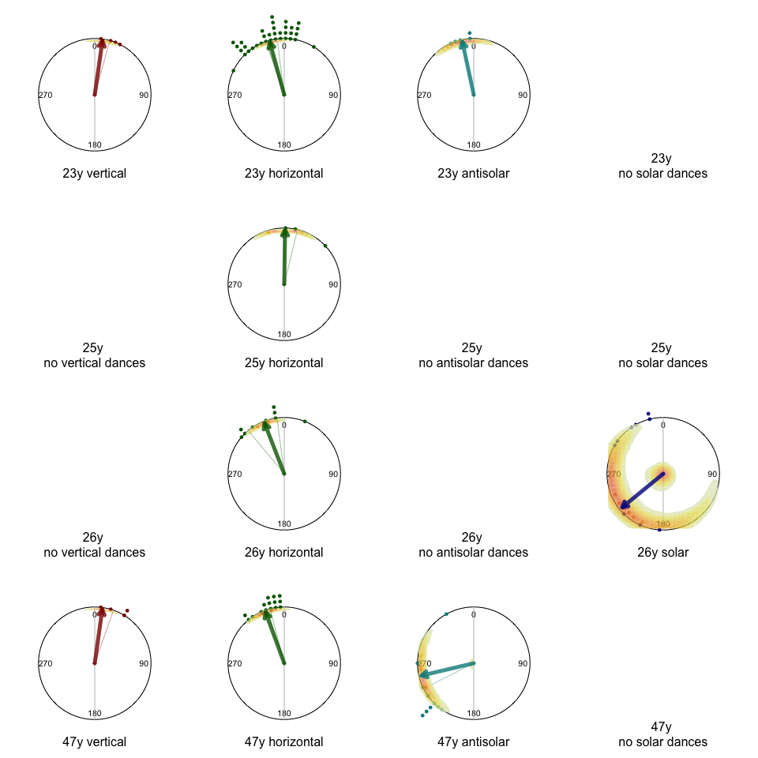

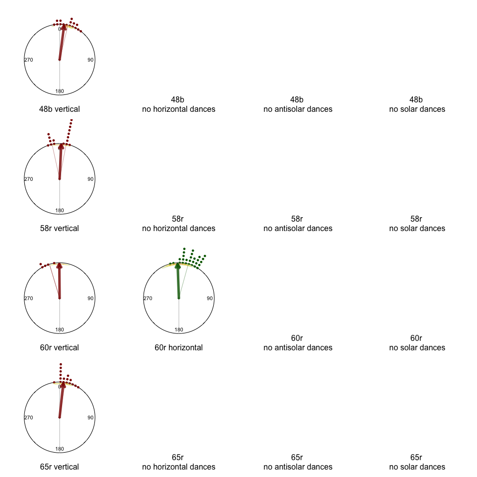

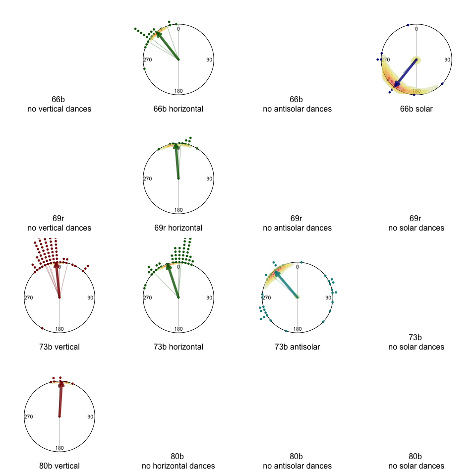

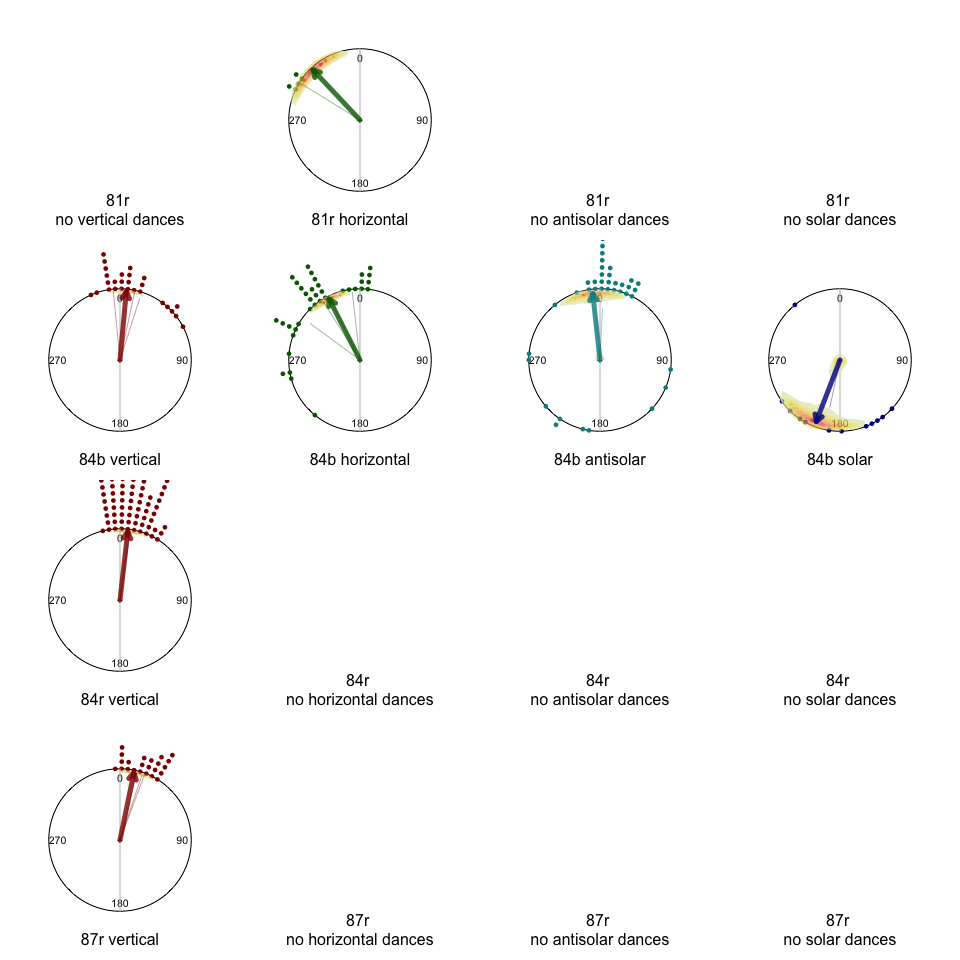

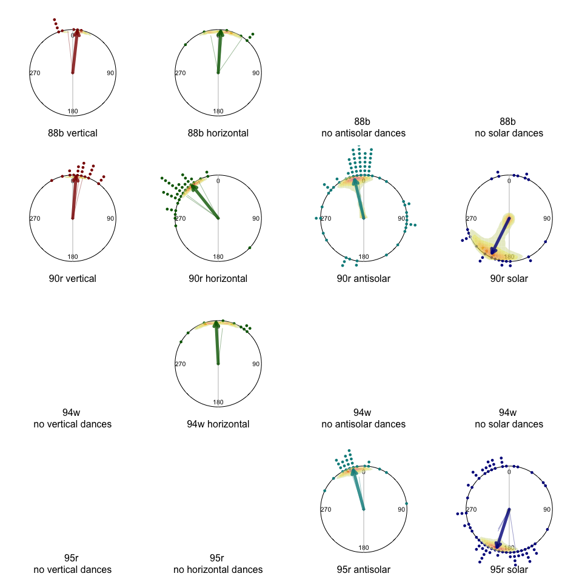

```r
par(pty = 's')
par(mar = c(0,0,0,0),
    mfrow = c(4,4) )
for(i in id_tab$Individual_nr)
{
  indiv = as.character(id_tab$ID[id_tab$Individual_nr == i])
  for(cnd in conds)
  {
    dt_ic = subset(hd,
                   Individual_nr == i &
                     condition %in% cnd)
    if(!nrow(dt_ic))
    {
      plot.new()
      mtext(text = paste(indiv, '\nno', cnd, 'dances'),
            side = 1,
            line = -2)
      next
    }
    with(dt_ic,
    {
      PCfun(angles = angle_deg,
           col = cond_cols[[cnd]],
           plot_rho = FALSE,
           title = paste(indiv, cnd))
      }
    )
    Draws2Cont(individual_draws[[i]],
             x_string = paste0('sin(mu$', cnd, ') * A1(softplus(kappa$', cnd, '))'),
             y_string = paste0('cos(mu$', cnd, ') * A1(softplus(kappa$', cnd, '))')
    )
    #dance estimates
    for(d in unique(dt_ic$Dance_nr))
    {
      arrows.circular(
        x = circular(mu_dance[d],
                     units = 'radians',
                     rotation = 'clock',
                     zero = pi/2),
        y = A1(softplus(kappa_dance[d])),
        lwd = 0.5,
        length = 0,
        col = adjustcolor(cond_cols[[cnd]], alpha.f = 200/255)
      )
    }
    #individual estimate
    arrows.circular(
      x = circular(mu_id[i, cnd],
                   units = 'radians',
                   rotation = 'clock',
                   zero = pi/2),
      y = A1(softplus(kappa_id[i, cnd])),
      lwd = 5,
      length = 0.1/1.25,
      col = adjustcolor(cond_cols[[cnd]], alpha.f = 0.8)
    )
  }
}
```

## Plot population level predictions

### Calculating empirical descriptors and paired shifts

This section calculates descriptive circular metrics from the raw data and identifies individuals that danced in each pair of conditions.

**Analysis Pipeline**

- **Circular Summary Extraction**: Computes mean vector lengths (`rho.circular`), maximum likelihood parameters (`MLE_est`), and Rayleigh uniformity tests (`Rayleigh_p`) for each individual in each condition using `aggregate`. These are saved to `mean_vectors`, alongside a linearised precision metric (`iskappa`).
- **Contrasts**: We compare each condition with the previous one in the progression (vertical → horizontal → antisolar → solar), as estimated directly by the model (H, A and S), and each condition with the vertical and horizontal conditions.
- **Empirical Delta Processing**: Calculates descriptive shifts in individual headings ($\Delta\mu$) for individuals that danced in both conditions of each contrast, using `MuDiff`.

```r
#calculate mean vectors
mean_vectors = aggregate(angle~ID*condition,
                         data = hd,
                         FUN = function(x){rho.circular(circular(x, template = 'none'))}
)
#correct names
mean_vectors = within(mean_vectors,
                      {mean_vector = angle; rm(angle)} # angle now indicates a mean vector, not an angle
)
#add kappa
mle_estimates = aggregate(angle~ID*condition,
                          data = hd,
                          FUN = MLE_est
)
#Rayleigh tests
rayleigh_tests = aggregate(angle~ID*condition,
                          data = hd,
                          FUN = Rayleigh_p
                          )
#add to the summary table and
#calculate inverse softplus kappa
mean_vectors = within(mean_vectors,
                      {
                        mu = deg(mle_estimates$angle[,'mu'])
                        kappa = mle_estimates$angle[,'kappa']
                        iskappa  = inv_softplus(kappa)
                        rayleigh_p = rayleigh_tests$angle
                      }
)

#Contrasts of interest: condition (first) relative to reference (second)
contrasts = list(
  c('horizontal', 'vertical'), # H
  c('antisolar', 'horizontal'), # A
  c('solar', 'antisolar'), # S
  c('antisolar', 'vertical'), # H + A
  c('solar', 'vertical'), # H + A + S
  c('solar', 'horizontal') # A + S
)
names(contrasts) = sapply(contrasts, paste, collapse = ' - ')

#individuals that danced in both conditions of each contrast
contrast_ids = lapply(contrasts,
                      function(cn)
                      {
                        id_tab$Individual_nr[id_cond[, cn[1]] & id_cond[, cn[2]]]
                      }
                      )
sapply(contrast_ids, length)
```

```
##  horizontal - vertical antisolar - horizontal      solar - antisolar
##                      9                      7                      5
##   antisolar - vertical       solar - vertical     solar - horizontal
##                      7                      4                      6
```

```r
#empirical differences in mean direction
mu_diffs = lapply(contrasts,
                  function(cn)
                  {
                    sapply(X = id_tab$ID[id_cond[, cn[1]] & id_cond[, cn[2]]],
                           FUN = MuDiff,
                           dta = mean_vectors,
                           vars = 'condition',
                           val = cn[1],
                           ref_val = cn[2])
                  }
                  )
```

### Visualising population-level circular predictions

This section generates population-level visualisations for the four conditions on a $2 \times 2$ grid layout. It combines empirical mean dance directions, individual estimates, and population model predictions.

**Visualisation Components**

- **Empirical Baselines**: Plots individual mean directions (`mu`) from the data using `PCfun`.
- **Individual Estimates**: Thin background arrows (`arrows.circular`) showing the median estimated mean$~$vector for each individual that danced in that condition.
- **Posterior Uncertainty Contours**: Uses `Draws2Cont` to summarise the model’s posterior distribution density for each condition.
- **Population Model Estimates**: Thick foreground arrow representing the population’s median estimated mean$~$vector.

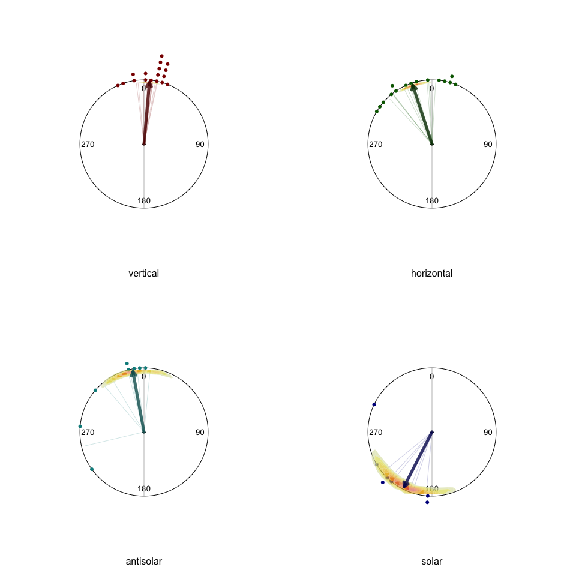

```r
par(pty = 's')
par(mfrow = c(2,2), mar = c(0,0,0,0))

for(cnd in conds)
{
  with(subset(mean_vectors, condition %in% cnd), {
    PCfun(angles = mu, col = cond_cols[[cnd]], shrink = 2, plot_rho = FALSE,
          title = cnd)
  })

  for(i in id_tab$Individual_nr[id_cond[, cnd]]) {
    arrows.circular(x = circular(x = mu_id[i, cnd], units = 'radians', rotation = 'clock', zero = pi/2),
                    y = A1(softplus(kappa_id[i, cnd])), lwd = 0.25, length = 0,
                    col = adjustcolor(cond_cols[[cnd]], alpha.f = 200/255))
  }

  Draws2Cont(draws = draws_final,
             x_string = paste0('sin(', MuString(cnd), ') * A1(softplus(', KappaString(cnd), '))'),
             y_string = paste0('cos(', MuString(cnd), ') * A1(softplus(', KappaString(cnd), '))'))

  arrows.circular(x = circular(x = MedCDraws(pop_draws$mu[[cnd]]),
                               units = 'radians',
                               rotation = 'clock', zero = pi/2),
                  y = A1(median(softplus(pop_draws$kappa[[cnd]]))),
                  lwd = 5, length = 0.1/1.25,
                  col = adjustcolor(cond_cols[[cnd]], alpha.f = 200/255, offset = c(rep(-0.2,3),0) )
  )
}
```

```r
for(cnd in conds)
{
  print(paste(cnd, "mean direction"))
  print(QDegDraws(pop_draws$mu[[cnd]]))
}
```

```
## [1] "vertical mean direction"
##   50%  2.5% 97.5%
##     5    -3    13
## [1] "horizontal mean direction"
##   50%  2.5% 97.5%
##   -18   -31    -4
## [1] "antisolar mean direction"
##   50%  2.5% 97.5%
##   -10   -44    26
## [1] "solar mean direction"
##   50%  2.5% 97.5%
##  -153  -197  -113
```

### Plotting relative population-level effects

This section visualises the differences in direction between conditions and prints summary quantiles for the directional shifts.

**Visualisation Components**

- **Empirical Differences**: Plots the observed differences in mean dance angle for individuals that danced in both conditions, using `PCfun`.
- **Individual Vectors**: median estimates of the change in direction for each of those individuals.
- **Posterior Densities**: Projects posterior distribution contours for the difference in population mean direction, using `Draws2Cont`. For successive conditions, this is the corresponding model effect, scaled by the concentration of that effect across individuals (e.g. `S|Individual_kappa`). Where a contrast spans several successive effects, the individual effects of each contribute, so the expected mean vector length of their sum is the product of their mean vector lengths (e.g. `A1(A|Individual_kappa) * A1(S|Individual_kappa)`). N.B. these concentrations are estimated directly (LogNormal prior), so they are not transformed by `softplus`.
- **Population Shift**: Overlays a thick arrow representing the estimated median population-level shift.
- **Turn Size Quantiles**: Computes and prints the median and $95\%$ credible intervals for the directional shift and the mean individual turning magnitude.

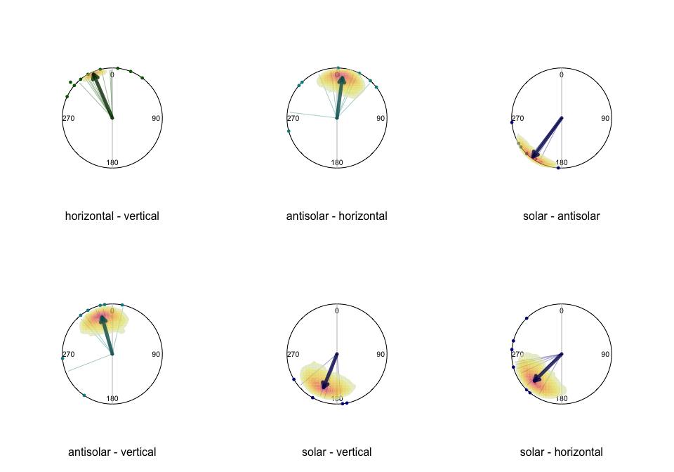

```r
par(pty = 's')
par(mfrow = c(2,3), mar = c(0,0,0,0))

#Strings for the difference in mean direction and its concentration across individuals
#effects in the first condition but not the second are added,
#effects in the second but not the first are subtracted
DiffString = function(cn)
{
  plus = setdiff(cond_effs[[cn[1]]], cond_effs[[cn[2]]])
  minus = setdiff(cond_effs[[cn[2]]], cond_effs[[cn[1]]])
  paste0(paste(plus, collapse = ' + '),
         if(length(minus)){paste0(' - ', paste(minus, collapse = ' - '))}else{''})
}
RhoString = function(cn)
{
  effs = union(setdiff(cond_effs[[cn[1]]], cond_effs[[cn[2]]]),
               setdiff(cond_effs[[cn[2]]], cond_effs[[cn[1]]]))
  paste0('A1(`', effs, '|Individual_kappa`)', collapse = ' * ')
}

contrast_table = data.frame()
for(cname in names(contrasts))
{
  cn = contrasts[[cname]]
  diff_draws = EvalDraws(DiffString(cn))
  rho_draws = EvalDraws(RhoString(cn))

  PCfun(angles = unlist(mu_diffs[[cname]]),
        col = cond_cols[[cn[1]]],
        shrink = 2,
        plot_rho = FALSE,
        title = cname)

  for(i in contrast_ids[[cname]]) {
    arrows.circular(x = circular(x = mu_id[i, cn[1]] - mu_id[i, cn[2]],
                                 units = 'radians',
                                 rotation = 'clock',
                                 zero = pi/2),
                    y = A1(softplus(kappa_id[i, cn[1]])),
                    lwd = 0.5,
                    length = 0,
                    col = adjustcolor(cond_cols[[cn[1]]], alpha.f = 200/255))
  }
  #scale by alignment _across_ individuals
  Draws2Cont(draws = draws_final,
             x_string = paste0('sin(', DiffString(cn), ') * ', RhoString(cn)),
             y_string = paste0('cos(', DiffString(cn), ') * ', RhoString(cn)))

  arrows.circular(x = circular(x = MedCDraws(diff_draws),
                               units = 'radians',
                               rotation = 'clock',
                               zero = pi/2),
                  y = median(rho_draws),
                  lwd = 5,
                  length = 0.1/1.25,
                  col = adjustcolor(cond_cols[[cn[1]]], alpha.f = 200/255, offset = c(rep(-0.2,3),0))
  )

  #individual turns: for individuals that danced in both conditions
  if(length(contrast_ids[[cname]]))
  {
    turn_mat = sapply(contrast_ids[[cname]],
                      function(i)
                      {
                        abs(mod_circular(individual_draws[[i]]$mu[[cn[1]]] -
                                           individual_draws[[i]]$mu[[cn[2]]]))
                      }
    )
    tq = QDraws(deg(rowMeans(as.matrix(turn_mat))), digits = 0)
  }else
  {
    tq = rep(NA, 3)
  }
  dq = QDegDraws(diff_draws)
  contrast_table = rbind(contrast_table,
                         data.frame(contrast = cname,
                                    n_ind = length(contrast_ids[[cname]]),
                                    dmu_median = dq[1], dmu_lower = dq[2], dmu_upper = dq[3],
                                    turn_median = tq[1], turn_lower = tq[2], turn_upper = tq[3],
                                    row.names = NULL)
  )
}
```

```r
print("Change in population mean direction (dmu) and mean individual turn size (turn), degrees")
```

```
## [1] "Change in population mean direction (dmu) and mean individual turn size (turn), degrees"
```

```r
print(contrast_table)
```

```
##                 contrast n_ind dmu_median dmu_lower dmu_upper turn_median
## 1  horizontal - vertical     9        -23       -36        -9          26
## 2 antisolar - horizontal     7          8       -26        42          32
## 3      solar - antisolar     5       -144      -171      -112         145
## 4   antisolar - vertical     7        -16       -49        22          37
## 5       solar - vertical     4       -158      -202      -116         151
## 6     solar - horizontal     6       -135      -179       -95         118
##   turn_lower turn_upper
## 1         18         34
## 2         17         46
## 3        120        166
## 4         20         50
## 5        130        165
## 6         91        143
```

### Visualising consistency predictions

**Visualisation & Summary Components**

- **Consistency ($\kappa$)**: Plots a $1 \times 4$ grid of vertical histograms (`VertHist`) showing the posterior density of estimated concentration parameters for each condition.
- **Quantile Reporting**: Computes median estimates and $95\%$ credible intervals for each condition (see `pred_table` above).

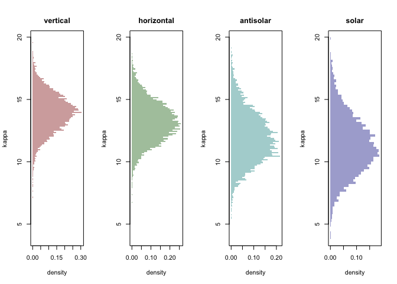

```r
#plot kappa
par(mfrow = c(1,4))
kappa_lim = range(softplus(unlist(pop_draws$kappa)))

for(cnd in conds)
{
  VertHist(data = softplus(pop_draws$kappa[[cnd]]),
           main = paste0('\n', cnd),
           ylab = 'kappa',
           ylim = kappa_lim,
           col = adjustcolor(cond_cols[[cnd]], alpha.f = 100/255),
           cex.axis = 0.7)
}
```

```r
print(pred_table[, c('condition', 'kappa_median', 'kappa_lower', 'kappa_upper')])
```

```
##    condition kappa_median kappa_lower kappa_upper
## 1   vertical        13.99       10.90       16.84
## 2 horizontal        13.17       10.16       16.46
## 3  antisolar        11.85        8.37       16.18
## 4      solar        11.19        7.18       16.11
```

### Changes in consistency

- **Contrast Effects ($\Delta\kappa$)**: Plots the change in concentration for each contrast, with a dashed baseline marker (`abline`) at no change.

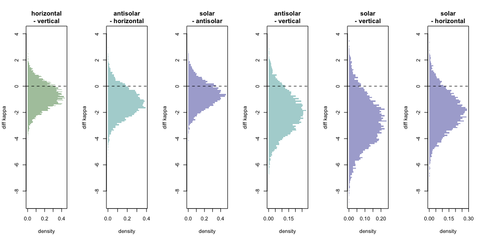

```r
# Plot difference in kappa
par(mfrow = c(1,6))

kappa_diffs = lapply(contrasts,
                     function(cn)
                     {
                       softplus(pop_draws$kappa[[cn[1]]]) -
                         softplus(pop_draws$kappa[[cn[2]]])
                     }
                     )
rho_diffs = lapply(contrasts,
                   function(cn)
                   {
                     A1(softplus(pop_draws$kappa[[cn[1]]])) -
                       A1(softplus(pop_draws$kappa[[cn[2]]]))
                   }
                   )
diff_lim = range(unlist(kappa_diffs))
for(cname in names(contrasts))
{
  VertHist(data = kappa_diffs[[cname]],
           main = paste0('\n', gsub(' - ', '\n- ', cname)),
           ylab = 'diff kappa',
           ylim = diff_lim,
           col = adjustcolor(cond_cols[[contrasts[[cname]][1]]], alpha.f = 100/255),
           cex.axis = 0.7)
  abline(h = 0, lty = 2)
}
```

```r
#Report effects
kappa_contrast_table = do.call(rbind,
                               lapply(names(contrasts),
                                      function(cname)
                                      {
                                        kq = QDraws(kappa_diffs[[cname]])
                                        rq = QDraws(rho_diffs[[cname]], digits = 3)
                                        data.frame(contrast = cname,
                                                   dkappa_median = kq[1], dkappa_lower = kq[2], dkappa_upper = kq[3],
                                                   drho_median = rq[1], drho_lower = rq[2], drho_upper = rq[3],
                                                   p_less_consistent = round(mean(kappa_diffs[[cname]] < 0), 3),
                                                   row.names = NULL)
                                      }
                               )
)
print(kappa_contrast_table)
```

```
##                 contrast dkappa_median dkappa_lower dkappa_upper drho_median
## 1  horizontal - vertical         -0.74        -2.66         1.17      -0.002
## 2 antisolar - horizontal         -1.25        -3.34         0.91      -0.004
## 3      solar - antisolar         -0.67        -2.58         1.26      -0.002
## 4   antisolar - vertical         -1.98        -4.85         1.00      -0.006
## 5       solar - vertical         -2.65        -6.19         1.01      -0.009
## 6     solar - horizontal         -1.92        -4.69         1.02      -0.007
##   drho_lower drho_upper p_less_consistent
## 1     -0.009      0.003             0.773
## 2     -0.016      0.002             0.875
## 3     -0.016      0.005             0.756
## 4     -0.021      0.003             0.902
## 5     -0.032      0.003             0.923
## 6     -0.027      0.003             0.900
```

### Visualising the concentration across individuals and dances

To interpret how similarly individuals and dances were oriented, we extract the posterior distributions for the group-level concentrations ($\kappa_\mu$). These were estimated directly as von Mises concentrations (LogNormal priors), so no transformation is needed.

**Analysis Workflow**

- **Scale Transformation**: Since some effects may be extremely consistent ($\kappa_{\mu} \to \infty$), they are plotted on a $\log_{10}$ scale.
- **Custom Axis Mapping**: To maintain intuitive interpretation, custom logarithmic axis ticks (`lticks`) are overlaid with the original linear values as text labels.
- **Contrast Profiles**: “Vertical” (`1|Individual_kappa`) is the concentration of individual mean directions around the population mean for vertical dances, the “horizontal”, “antisolar” and “solar” effects (`H|Individual_kappa`, `A|Individual_kappa`, `S|Individual_kappa`) are the concentrations of individual changes in direction from the previous condition in the progression, and “dances” (`1|Dance_kappa`) is the concentration of dance mean directions around their individual’s mean direction.

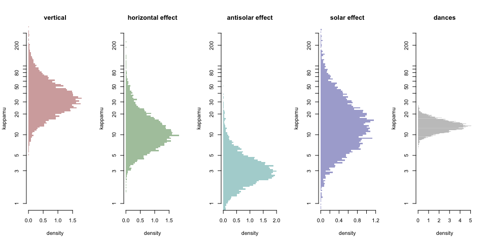

```r
#plot kappa
par(mfrow = c(1,5))

lticks = c(1,3,5, 1:10*10, 200, 300)
kappamu_params = c(vertical = '1|Individual_kappa',
                   horizontal = 'H|Individual_kappa',
                   antisolar = 'A|Individual_kappa',
                   solar = 'S|Individual_kappa',
                   dances = '1|Dance_kappa')
kappamu_cols = c(cond_cols, dances = 'gray50')

for(nm in names(kappamu_params))
{
  VertHist(data = log10(draws_final[[kappamu_params[nm]]]),
           main = paste0('\n', nm, if(nm %in% c('horizontal', 'antisolar', 'solar')){' effect'}else{''}),
           ylab = 'kappamu',
           ylim = log10(c(1, 300)),
           col = adjustcolor(kappamu_cols[[nm]], alpha.f = 100/255),
           axes = FALSE,
           cex.axis = 0.7)
  axis(1)
  axis(2, at = log10(lticks), labels = lticks)
}
```

```r
kappamu_table = do.call(rbind,
                        lapply(names(kappamu_params),
                               function(nm)
                               {
                                 q = QDraws(draws_final[[kappamu_params[nm]]])
                                 data.frame(parameter = kappamu_params[nm],
                                            median = q[1], lower = q[2], upper = q[3],
                                            row.names = NULL)
                               }
                        )
)
print(kappamu_table)
```

```
##            parameter median lower  upper
## 1 1|Individual_kappa  32.70 11.72 112.78
## 2 H|Individual_kappa  10.55  3.81  43.45
## 3 A|Individual_kappa   2.99  1.10  10.67
## 4 S|Individual_kappa  13.49  2.76  85.05
## 5      1|Dance_kappa  13.34  9.01  19.80
```

### Estimate the posterior distribution of concentration across individuals

To evaluate the consistency of individual directional preferences within each condition, we estimate the population’s concentration parameter, $\kappa_{\mu}$, using a von$~$Mises distribution. This converts our nested list of individual MCMC draws into $Draw \times Individual$ matrices for each condition. Only individuals that danced in each condition are included.

**Analysis Workflow**

- **Maximum Likelihood Estimation (MLE)**: The model only explicitly estimated across-individual concentration for the vertical condition and for the *successive condition differences*, so across-individual concentration *within* each other condition needs to be estimated from the model’s posterior draws. For each MCMC draw (row), we compute the Maximum Likelihood Estimate for $\kappa$ using `mle.vonmises`.
- **Posterior Profiling**: By applying this MLE estimation across every draw, we reconstruct the full posterior distribution for $\kappa_{\mu}$ under each condition.

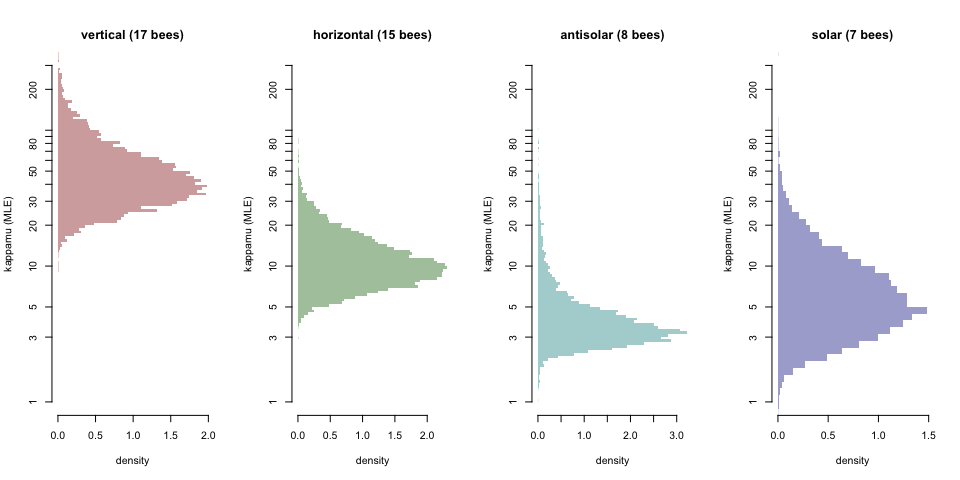

```r
# ==========================================
# MATRIX RECONSTRUCTION & HELPER FUNCTIONS
# ==========================================

# Helper function to extract a specific condition across selected individuals
# Builds a Draw-by-Individual matrix
get_mu_matrix = function(
  cond,
  inds
) {
  # sapply combines the resulting vectors into columns of a single matrix
  sapply(inds, function(i) individual_draws[[i]]$mu[[cond]])
}

# Function to calculate the MLE kappa (concentration parameter) for a single draw row
calc_kappa_mle = function(
  mu_row
) {
  # mle.vonmises returns a complex list object; we extract only the numeric $kappa estimate
  as.numeric(mle.vonmises(circular(mu_row, units='radians'))$kappa)
}

# ==========================================
# POSTERIOR ESTIMATION VIA APPLY
# ==========================================
# For individuals observed in each condition
post_kappamu = lapply(setNames(conds, conds),
                      function(cnd)
                      {
                        mu_mat = get_mu_matrix(cnd, id_tab$Individual_nr[id_cond[, cnd]])
                        apply(mu_mat, 1, calc_kappa_mle)
                      }
                      )

# ==========================================
# VISUALIZATION (VERTICAL HISTOGRAMS)
# ==========================================
par(mfrow = c(1,4))

for(cnd in conds)
{
  VertHist(data = log10(post_kappamu[[cnd]]),
           main = paste0('\n', cnd, ' (', sum(id_cond[, cnd]), ' bees)'),
           ylab = 'kappamu (MLE)',
           ylim = log10(c(1, 300)),
           col = adjustcolor(cond_cols[[cnd]], alpha.f = 100/255),
           axes = FALSE,
           cex.axis = 0.7)
  axis(1)
  axis(2, at = log10(lticks), labels = lticks)
}
```

```r
kappamu_mle_table = do.call(rbind,
                            lapply(conds,
                                   function(cnd)
                                   {
                                     q = QDraws(post_kappamu[[cnd]])
                                     rq = QDraws(A1(post_kappamu[[cnd]]), digits = 3)
                                     data.frame(condition = cnd,
                                                n_ind = sum(id_cond[, cnd]),
                                                kappamu_median = q[1], kappamu_lower = q[2], kappamu_upper = q[3],
                                                rho_median = rq[1], rho_lower = rq[2], rho_upper = rq[3],
                                                row.names = NULL)
                                   }
                            )
)
print(kappamu_mle_table)
```

```
##    condition n_ind kappamu_median kappamu_lower kappamu_upper rho_median
## 1   vertical    17          42.77         19.21        141.05      0.988
## 2 horizontal    15          10.20          5.23         27.91      0.950
## 3  antisolar     8           3.56          2.20         15.35      0.844
## 4      solar     7           5.63          1.94         25.90      0.906
##   rho_lower rho_upper
## 1     0.974     0.996
## 2     0.899     0.982
## 3     0.728     0.967
## 4     0.688     0.981
```

# Appendix

## Plot individual means

Print all individual and dance effects in this model.

### Mean angle

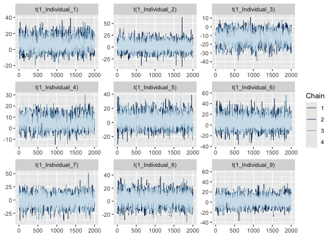

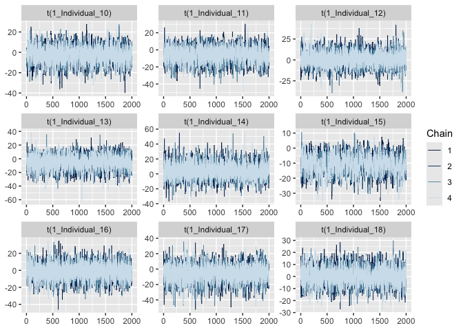

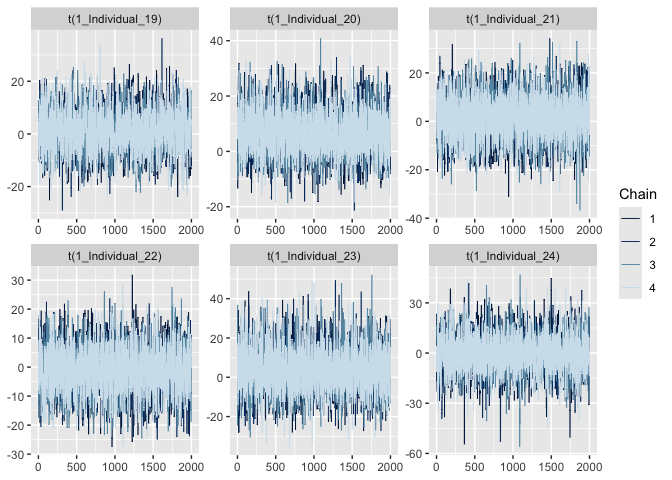

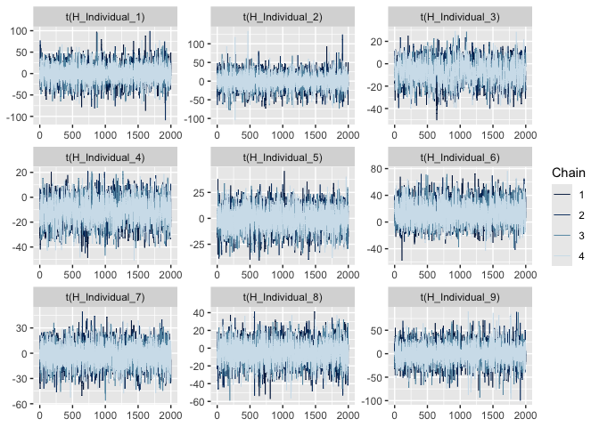

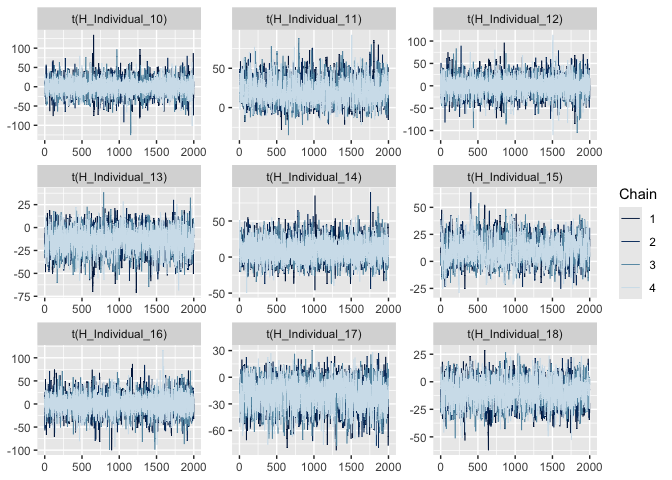

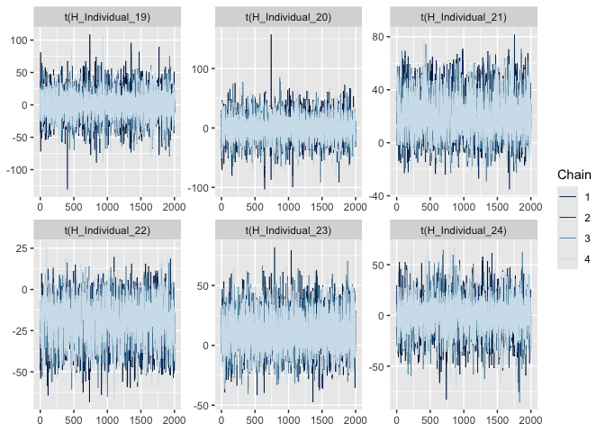

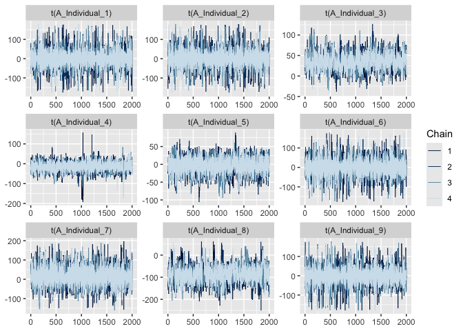

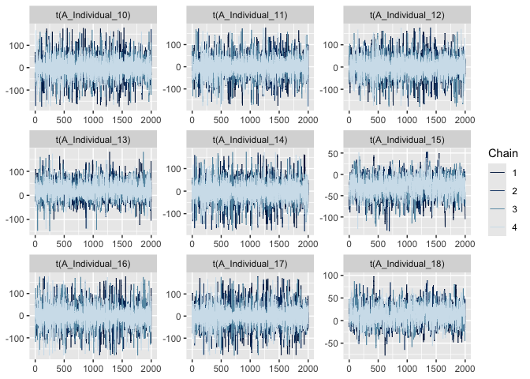

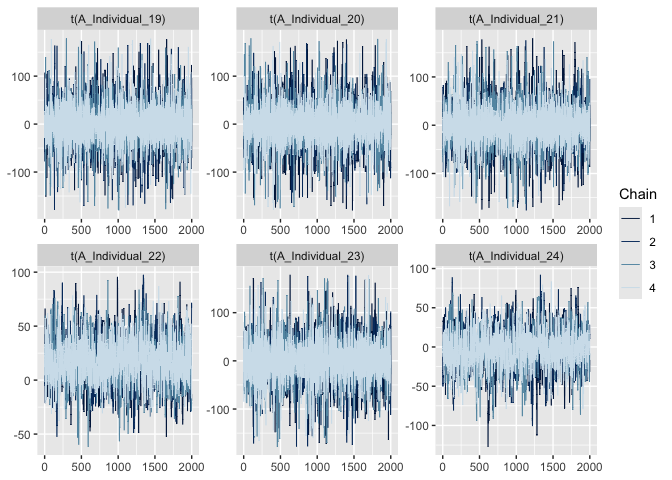

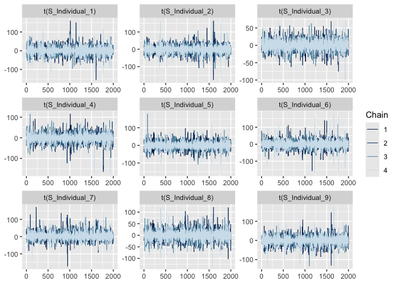

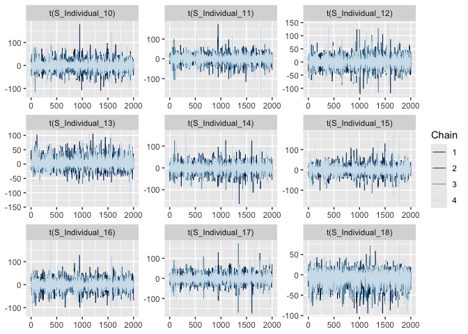

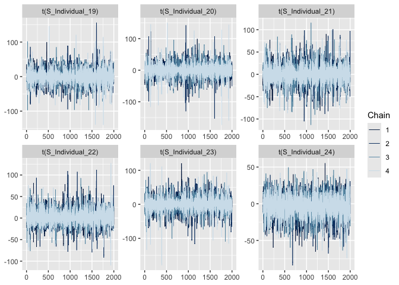

[14 more figures not shown]

```r
plt_panels = 9
for(base in c("1_Individual_", "H_Individual_", "A_Individual_", "S_Individual_", "1_Dance_"))
{
  n_lvl = if(grepl('Dance', base)){n_dance}else{n_ind}
  for(id in 0:(ceiling(n_lvl/plt_panels)-1))
  {
    # Calculate the specific range of indices for this page
    start_idx = (id * plt_panels) + 1
    end_idx   = min((id + 1) * plt_panels, n_lvl)
    plt = mcmc_trace(draws_final,
                     pars = paste0(base,
                                   start_idx:end_idx),
                     facet_args = list(ncol = 3,
                                       nrow = 3),
                     transformations = unwrap_circular_deg
    )
    print(plt)
  }
}
```